# Analysis of 2021 VPHi clinical Survey data

Raphaëlle Lesage

%Copyright (c) 2023 - Virtual Physiological Human institute (VPHi)

%Distributed under the GPLv3 License. % This program is free software: you can redistribute it and/or modify % it under the terms of the GNU General Public License as published by % the Free Software Foundation, either version 3 of the License, or % (at your option) any later version. % You should have received a copy of the GNU General Public License % along with this program. If not, see https://www.gnu.org/licenses/

# Setup environment

## Load librabries

```r
##set up chunk
# path management packages

# wrangling packages
library (here)
library(tidyverse) # for tidyr and dplyr
#library(data.table) #alternative to dplyr to work with table as sql

# analysis packages
library(coin) #for ordinal data analysis (Agresti, 2007)
library('DescTools')

# plotting packages
library(ggplot2) # ggplot environment
library(ggpubr) # publication ready plots
library(viridis) #color palet (yellow to blue)
library(corrplot)
library("gplots") #for balloonplot
```

## Define path for storing results (here)

```r
outfile_name <- "Preprocessed_data.Rds"
here::i_am("2021_VPHi_clinical_survey_data_clean.csv")
```

```
here() starts at C:/Users/u0114452/Documents/Zenodo_clinical_survey_data_and_analysis
```

```r
here = here::here()
output_folder = "Output"
```

## Load pre-processed data

```r
save_file_path <- here(output_folder, outfile_name)
tdf <- readRDS(save_file_path)
rawdata <- readRDS(here(here,output_folder,"Raw_data.Rds"))
```

# Analysis

Define Likert scales’ levels

```r
Awareness_levels= c('Not at all aware','Slightly aware','Moderately aware','Very aware','Extremely aware')
#Familiarity_levels= c('','Not at all familiar','Slightly familiar','Moderately familiar','Very familiar','Extremely familiar')
#Agreement_levels= c('','Strongly disagree','Disagree','Neutral','Agree','Strongly agree')
```

```r
#glimpse(tdf)
```

## Awareness and familiarity

Level of awareness in in silico concepts and terms:

```r
summary(tdf[,5:10])
```

```
 Q1.In.silico.medicine.awareness Q1.Patient.specific.modelling.awareness Q1.In.silico.clinical.trials.awareness Q1.Virtual.Physiological.Human.awareness
 Not at all aware:36             Not at all aware:16                     Not at all aware:42                    Not at all aware:47
 Slightly aware  :33             Slightly aware  :26                     Slightly aware  :54                    Slightly aware  :30
 Moderately aware:31             Moderately aware:39                     Moderately aware:27                    Moderately aware:39
 Very aware      :36             Very aware      :46                     Very aware      :26                    Very aware      :31
 Extremely aware :25             Extremely aware :36                     Extremely aware :13                    Extremely aware :15
 NA's            : 2                                                     NA's            : 1                    NA's            : 1
 Q1.Personalized.medicine.awareness    Q1.Digital.Twin.awareness
 Not at all aware:12                Not at all aware:68
 Slightly aware  :28                Slightly aware  :27
 Moderately aware:33                Moderately aware:32
 Very aware      :52                Very aware      :24
 Extremely aware :37                Extremely aware :12
 NA's            : 1
```

```r
# print("Patient.specific.modelling.awareness :")
# table(tdf$Q1.Patient.specific.modelling.awareness)
# p1= prop.table(table(tdf$Q1.Patient.specific.modelling.awareness))*100
```

Visualize data:

```r
p1= prop.table(table(tdf$Q1.Patient.specific.modelling.awareness))*100
p2= prop.table(table(tdf$Q1.In.silico.clinical.trials.awareness))*100
p3= prop.table(table(tdf$Q1.Virtual.Physiological.Human.awareness))*100
p4= prop.table(table(tdf$Q1.Personalized.medicine.awareness))*100
p5= prop.table(table(tdf$Q1.Digital.Twin.awareness))*100


## plot histograms
par(mfrow=c(3,2))
  b1 = barplot(p1, main = "Patient specific modelling")
  text(x = b1, y = p1, label = round(p1,1), pos = 1, cex = 1, col = "red")
```

```r
  b2 = barplot(p2, main = "In silico clinical trials")
  text(x = b2, y = p2, label = round(p2,1), pos = 1, cex = 1, col = "red")
```

```r
  b3 = barplot(p3, main = "Virtual Physiological Human")
  text(x = b3, y = p3, label = round(p3,1), pos = 1, cex = 1, col = "red")
```

```r
  b4 = barplot(p4, main = "Personalized medicine")
  text(x = b4, y = p4, label = round(p4,1), pos = 1, cex = 1, col = "red")
```

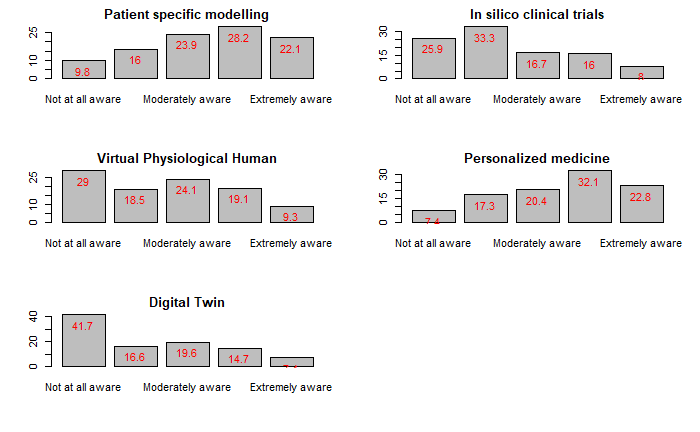

```r
  b5 = barplot(p5, main = "Digital Twin")
  text(x = b5, y = p5, label = round(p5,1), pos = 1, cex = 1, col = "red")
```

Total number of answers (not NA) per question:

```r
cat("In.silico.medicine.awareness:", sum(table(tdf$Q1.In.silico.medicine.awareness)),"\n")
```

```
In.silico.medicine.awareness: 161
```

```r
cat("Patient.specific.modelling.awareness:", sum(table(tdf$Q1.Patient.specific.modelling.awareness)),"\n")
```

```
Patient.specific.modelling.awareness: 163
```

```r
cat("In.silico.clinical.trials.awareness:", sum(table(tdf$Q1.In.silico.clinical.trials.awareness)),"\n")
```

```
In.silico.clinical.trials.awareness: 162
```

```r
cat("Virtual.Physiological.Human.awareness: ", sum(table(tdf$Q1.Virtual.Physiological.Human.awareness)),"\n")
```

```
Virtual.Physiological.Human.awareness:  162
```

```r
cat("Personalized.medicine.awareness:", sum(table(tdf$Q1.Personalized.medicine.awareness)),"\n")
```

```
Personalized.medicine.awareness: 162
```

```r
cat("Digital.Twin.awareness:", sum(table(tdf$Q1.Digital.Twin.awareness)),"\n")
```

```
Digital.Twin.awareness: 163
```